# Eyes: normal mixture model for microspectophotometric records

Puglisi - 1744998

05 aprile 2018

Bowmaker et al. (1985) analyze data on the peak sensitivity wavelengths for individual microspectophotometric records on a small set of monkey’s eyes. WinBUGs Examples Volume II gives the data for one monkey. Below we can see the histogram of the data with a kernel density estimate suggesting two - components normal mixture, as Bowmaker suggested. The considered type of monkey was found to have two cone pigments with peak sensitivities at approximately 536 and 550.

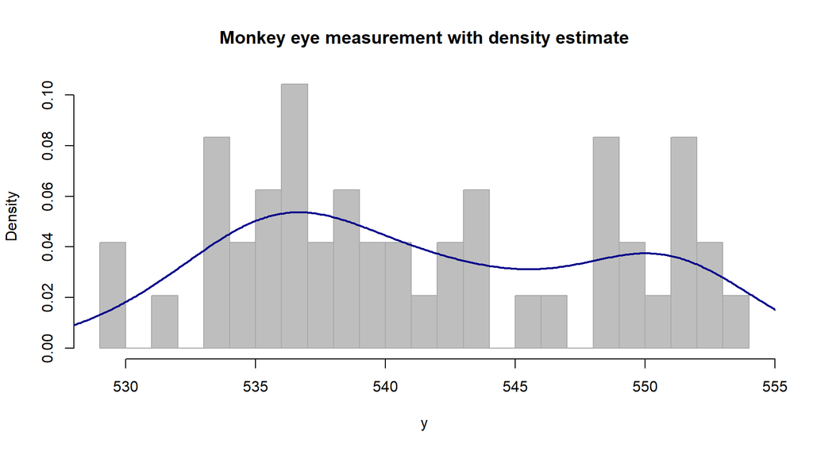

A tipical Normal Mixture model looks like this:
$$X|\underline{\theta} \sim \sum_{i=1}^{C} \omega_{c}N(x|\mu_{c}, \tau_{c})$$
Where $\underline{\theta}= (\underline{\mu}, \underline{\tau}, \underline{\omega})$ and $\omega_{c}$ are the mixture weights. We consider the parametrization of the normal density with the precision $\tau_{c}=1/\sigma^2_{c}$. We consider the following set of conjugate priors:

$$\mu_{c} \overset{\text{iid}}{\sim}N(\mu_{c},\tau_{c})
\\ \tau_{c} \overset{\text{iid}} {\sim} Gamma(a_{c},b_{c})
\\ \underline{\omega} \sim Dirichlet(\underline{\alpha}=(\alpha_{1},...,\alpha_{c}))$$

Also we can notice that the p-values for the second component leads to refuse the null hypothesis (H0: 1 component against 2 components), instead the second p-value leads to accept the 2 component model against a three component model.

```r
a$p.values
```

```
## [1] 0.02 0.61
```

Another instrument that I used to check for the number of components is the function GaussianMixture in the package SBic. This creates an object representing a family of mixture models up to a specified maximum number of components (maxNumComponents=15 considered), in particular it gives the BIC for each model considered. BIC attempts to resolve this overfitting problem by introducing a penalty term for the number of parameters in the model. In fact the BIC is defined as:
$$BIC= \ln(n)k-2ln(\hat{L})$$

As we can notice in the results, the more are the parameters, the more the model is penalized. Also the BIC gives the best output for the 2 component model.

```
##  [1] -165.0321 -161.7792 -165.8728 -166.9155 -171.0505 -176.8422 -181.6670
##  [8] -185.8982 -191.4818 -192.0680 -198.6602 -203.5727 -209.1685 -209.6870
## [15] -214.7866
```

### Simulated Data

Now, simulating data from 2 normal distribution with 0 and 10 i can start the analysis.

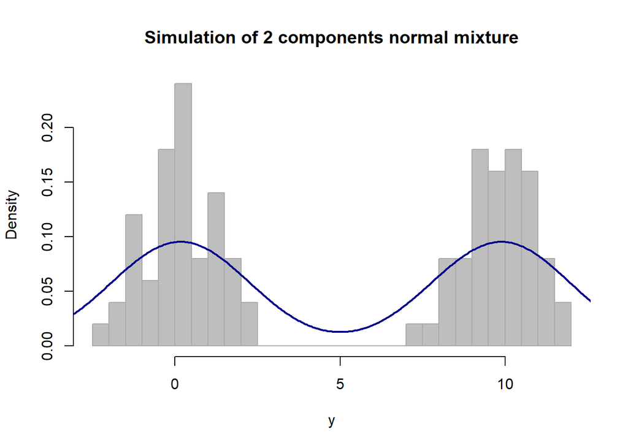

## Posterior Predictions on my own

```r
ParPost<- function(y, aDir, bDir, a, b, z, numiter, n0, mu0, tau20){
  EstMat<- matrix(0, numiter, 4)

  set.seed(12345)
  for (i in 1:numiter) {

    n=c(sum(z==1),sum(z==2))

    EmpMean=c(mean(y[z==1]),mean(y[z==2]))

    sy2 = c(sum((y[z==1]-EmpMean[1])^2),sum((y[z==2]-EmpMean[2])^2))

    # posterior delle dir (pesi delle componenti)
    #era una dir con marginale beta(aDIr, bDir) ---> beta(aDir+Nc, bDir+Nc)
    w = rbeta(1,aDir+n[1],bDir+n[2])

    # posterior del precision parameter
    # era una Gamma(a,b)----> gamma( )
    bgamma= c(b+(sy2[1])/2, b+(sy2[2])/2)
    SigmaPost = mean(rgamma(2,a+(n/2),bgamma))

    # posterior di mu
    # era una Norm(mu0, tau20)---> Norm(mc, tauc)

    tau_c= 1/(mean(tau20)+(length(y)*SigmaPost))
    delta<-(SigmaPost*length(y))/(mean(tau20)+(SigmaPost*length(y)))
    mu_c= (delta*EmpMean)+((1-delta)*mu0)
    MuPost = rnorm(2,mu_c,sqrt(tau_c))

    # post della multinomiale
    # era una M(1, w=(w1, w2))---> M(1, pc=(p1, p2))
    pz1=w*dnorm(y,MuPost[1],sqrt(1/SigmaPost[1]))
    pz2=(1-w)*dnorm(y,MuPost[2],sqrt(1/SigmaPost[1]))
    pz=pz1/(pz1+pz2)

    for (j in 1:length(y)) {
      z[j]=sample(1:2,size=1,prob=c(pz[j],1-pz[j]))}
    EstMat[i,]=c(w,MuPost,1/SigmaPost)
  }
  return(EstMat )
}
posteriors<- ParPost(y, aDir=0.5, bDir=0.5, a=0.01,b=0.01, z, numiter=20000, n0=c(1,1), mu0=mu, tau20=tau20)
```

```
## [1] "Loglikelihood Estimation"
```

```
## [1] -217.3075
```

```
## [1] "Estimated parameters"
```

```
## [1] "P"
```

```
## [1] 0.4996061
```

```
## [1] "Mu"
```

```
## [1] 0.1544421 9.8574485
```

```
## [1] "Sigma"
```

```
## [1] 1.06866
```

From the plots behind we can say that the function gives out values almost stationary, incorrelated and that follow the right density distribution.

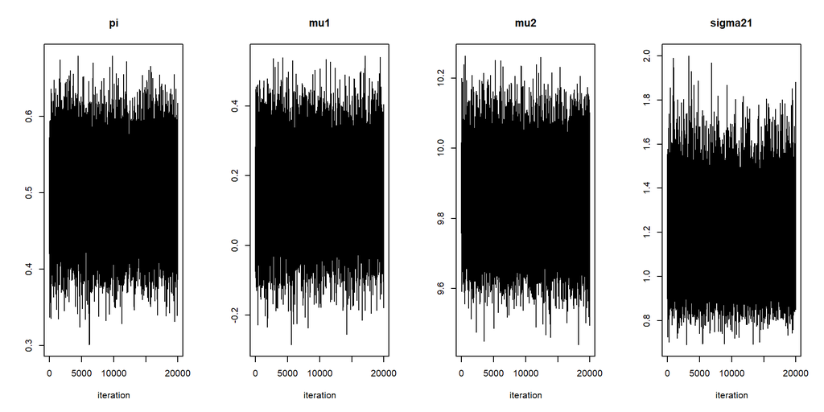

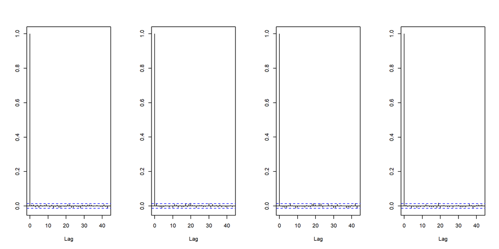

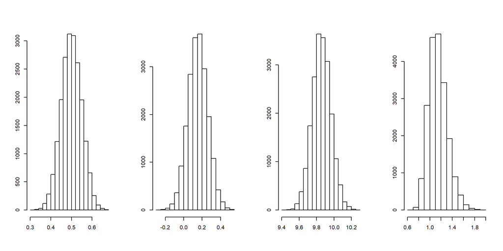

Hence, this procedure converges to a two component normal mixture,as we can see behind

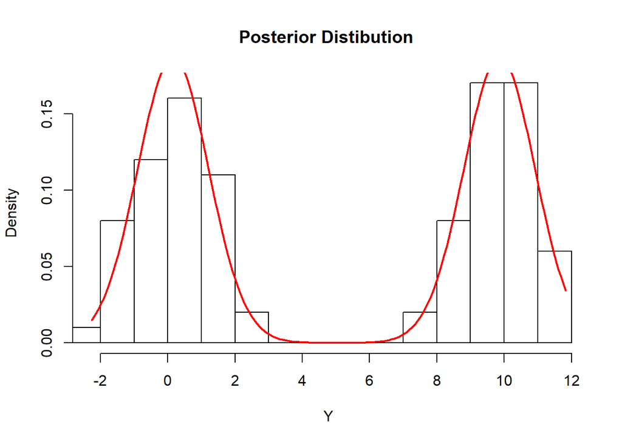

## Estimation via Rbugs

Now using Rbugs to esimate the parameter, and setting the prior specifications as previously, we have the following results:

```
## model is syntactically correct
## model is syntactically correct
```

```
## data loaded
```

```
## model compiled
```

```
## 1000 updates took 0 s
```

```
## monitor set for variable 'lambda'
```

```
## monitor set for variable 'sigma'
```

```
## monitor set for variable 'P'
```

```
## 20000 updates took 5 s
```

```
## $statistics
##                 Mean         SD     Naive SE Time-series SE
## P[1]      0.49971420 0.04963789 0.0002481895   0.0002481881
## P[2]      0.50028580 0.04963789 0.0002481895   0.0002481881
## lambda[1] 0.07178381 0.13427332 0.0006713666   0.0011628530
## lambda[2] 9.89625962 0.13316882 0.0006658441   0.0006658493
## sigma[1]  0.94561789 0.06826211 0.0003413105   0.0003569654
```

Now, to study the convergence of the results we use the Gelman diagnostics. This evaluates MCMC convergence by analyzing the difference between multiple Markov chains. The convergence is assessed by comparing the estimated between-chains and within-chain variances for each model parameter. Large differences between these variances indicate nonconvergence. The gelman.diag returns the “Scale Reduction Factors” for each parameter. A factor of 1 means that between chain variance and within chain variance are equal , larger values mean that there is still a notable difference between the computed chains. Let $\hat{I}^{m}=\frac {1}{T}\sum_{i=1}^{T} h(\theta_i^{(m)})$ and $\hat{I}_T$ the overall estimator which uses all the $M *T$ simulations. TThe between and within chain variances are given by:
$$B_T=\frac{1}{M} \sum_{m=1}^M (\hat{I}^{(m)} - \hat{I}_{T})^2 \\
W = \frac{1}{M} \sum_{m=1}^M [\frac{1}{T}\sum_{i=1}^{T}(h(\theta_i^{(m)})-\hat{I}^{(m)}_{T})^2]$$
So the Potential Scale Factor (PSRF) is:
$$R_T=\frac {\frac{T-1}{T}W_T+\frac{M+1}{M}B_T}{W_T}\frac{v_T}{v_t-2}$$
So if the M chains have converged to the target posterior distribution, then PSRF should be close to 1 and the assumption of homogeneity mean follows. From the results we can say that the chain have converged.

```
## Potential scale reduction factors:
##
##           Point est. Upper C.I.
## P[1]               1          1
## P[2]               1          1
## lambda[1]          1          1
## lambda[2]          1          1
## sigma[1]           1          1
##
## Multivariate psrf
##
## 1
```

Below we can see the gelman plot that shows the development of the scale-reduction over iterations, which is useful to see whether the reduction factor is also stable. Sometimes, the factors go down and then up again, as you will see)

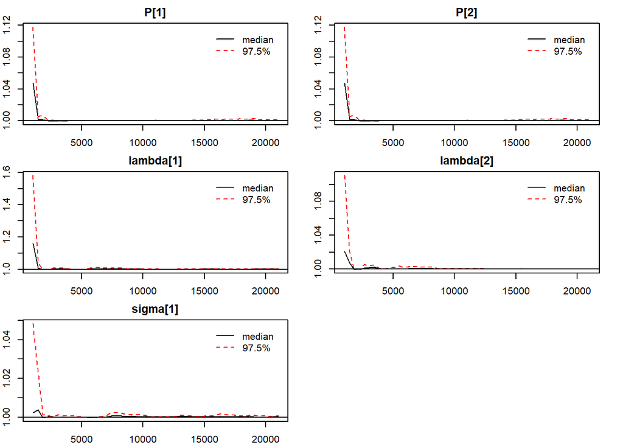

Here some statistics of the estimated parameter. Another time these are almost the same.

```
##
## Iterations = 1001:21000
## Thinning interval = 1
## Number of chains = 2
## Sample size per chain = 20000
##
## 1. Empirical mean and standard deviation for each variable,
##    plus standard error of the mean:
##
##              Mean      SD  Naive SE Time-series SE
## P[1]      0.49971 0.04964 0.0002482      0.0002482
## P[2]      0.50029 0.04964 0.0002482      0.0002482
## lambda[1] 0.07178 0.13427 0.0006714      0.0011629
## lambda[2] 9.89626 0.13317 0.0006658      0.0006658
## sigma[1]  0.94562 0.06826 0.0003413      0.0003570
##
## 2. Quantiles for each variable:
##
##              2.5%   97.5%
## P[1]       0.4035  0.5973
## P[2]       0.4027  0.5965
## lambda[1] -0.1901  0.3369
## lambda[2]  9.6379 10.1581
## sigma[1]   0.8240  1.0926
```

```
## [1] "Loglikelihood Estimation"
```

```
## [1] -203.8756
```

So we can notice that also here the posterior converge to the true distribution.

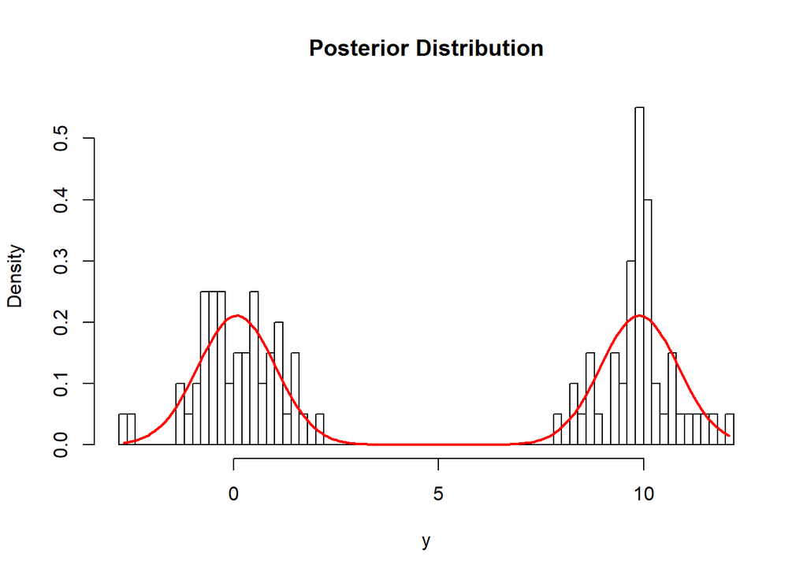

As previously we can check for stationariety, density and correlation of the estimated parameters.

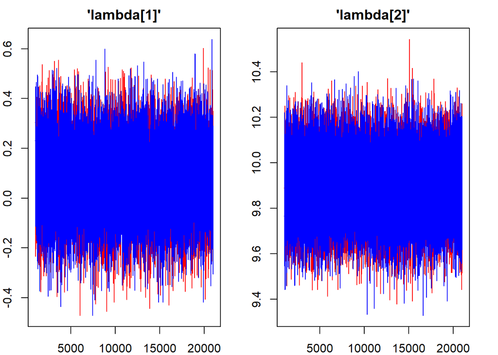

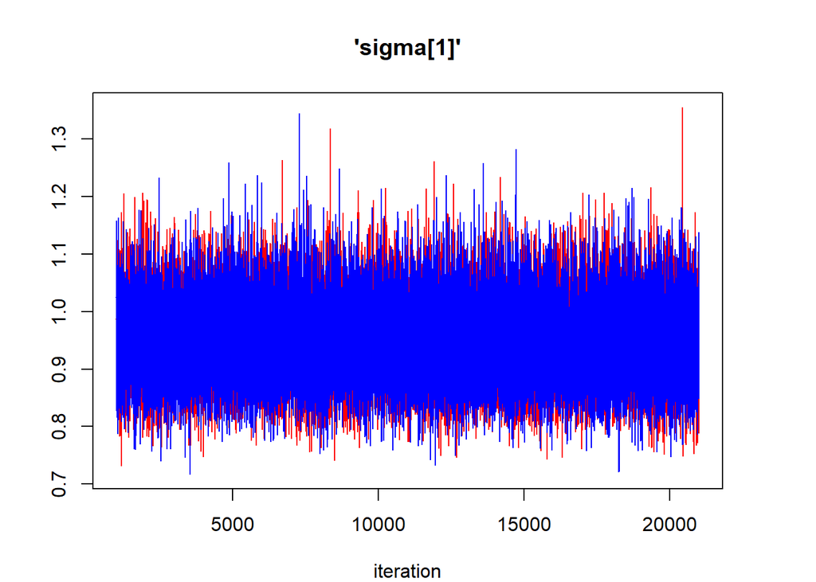

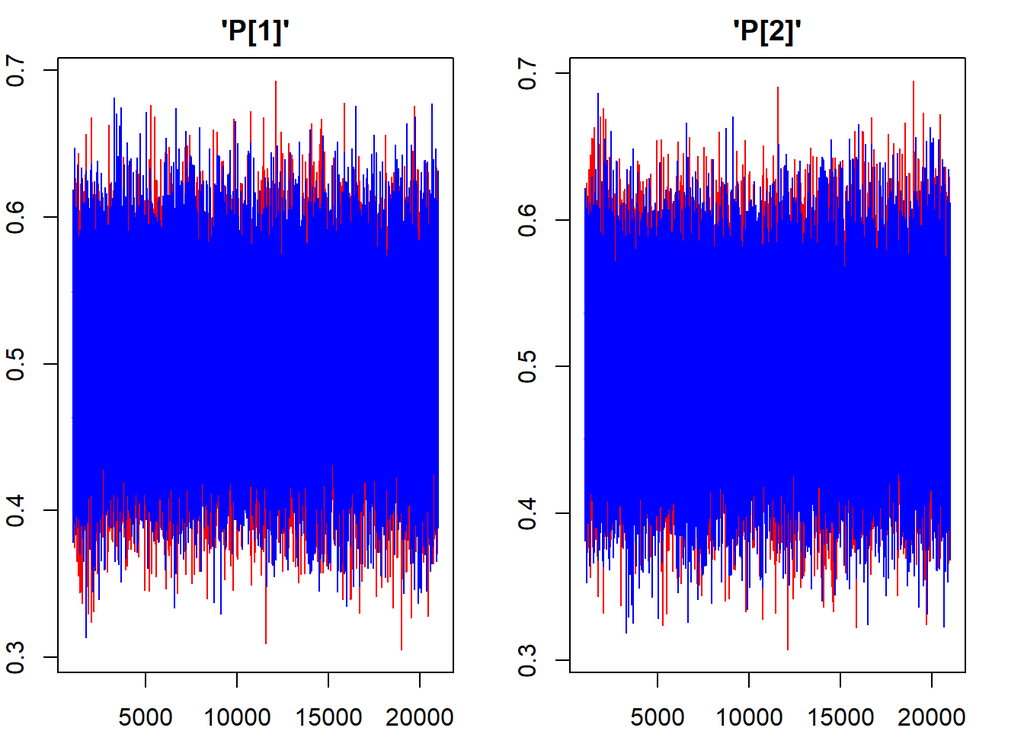

[figure not shown]

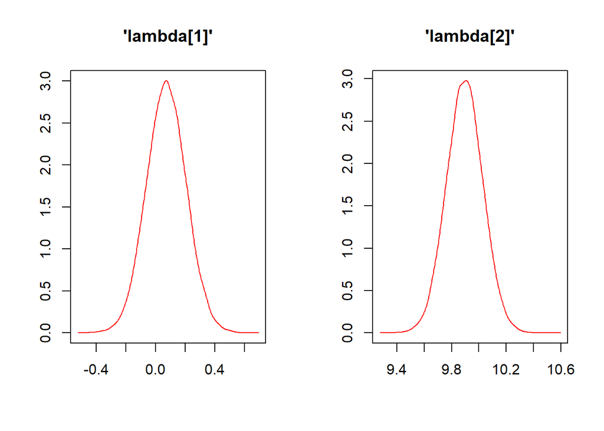

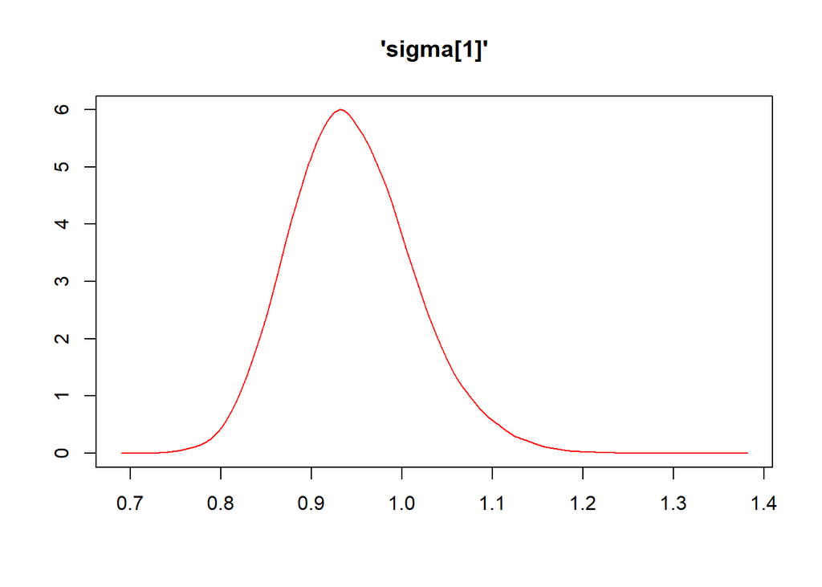

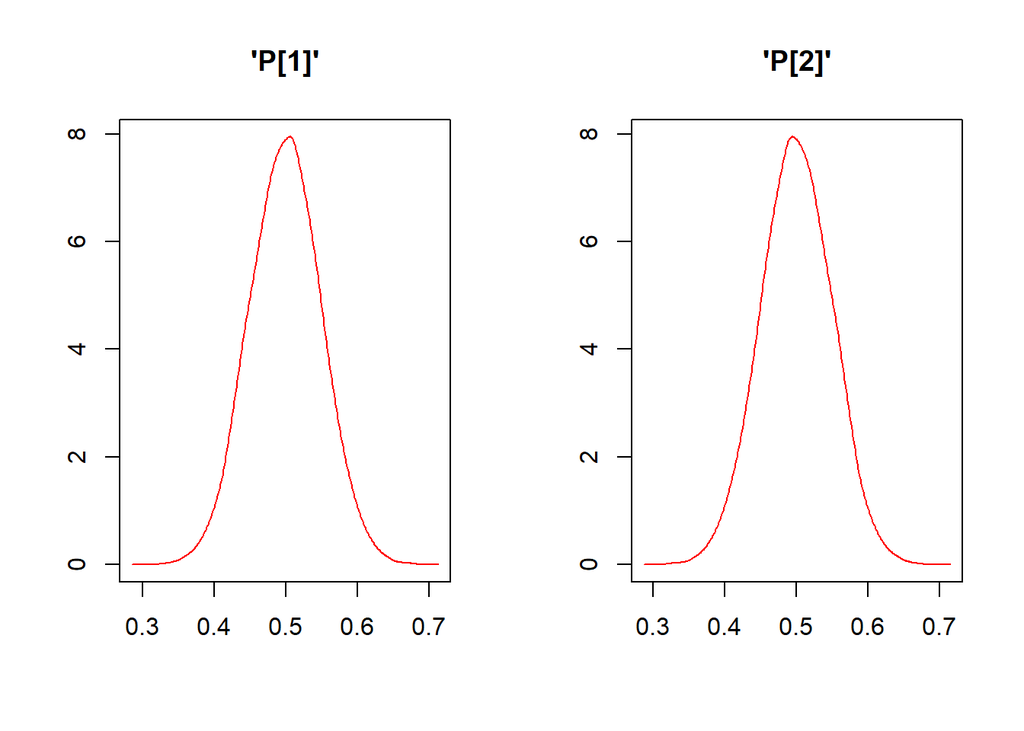

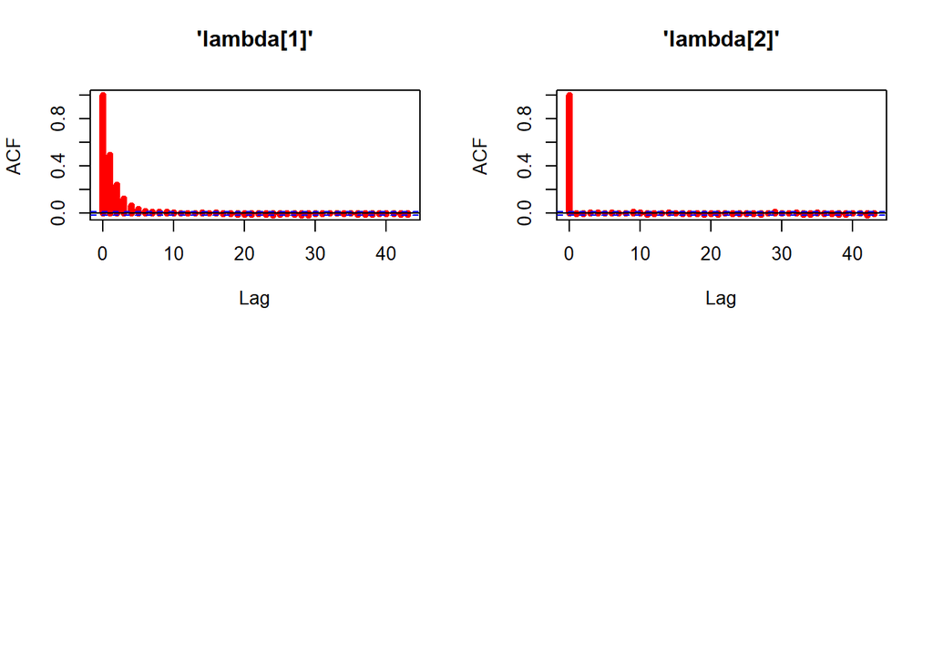

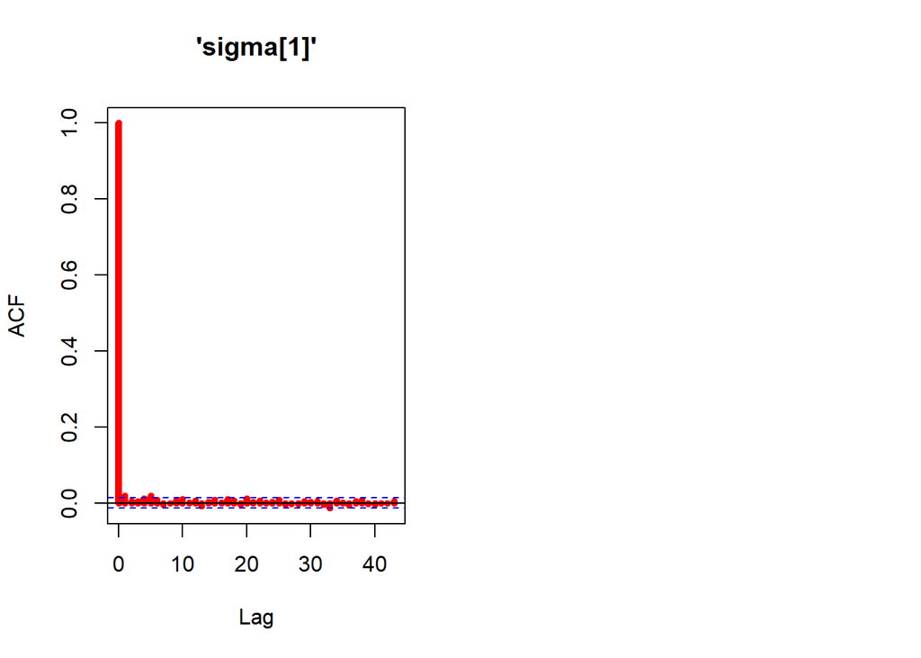

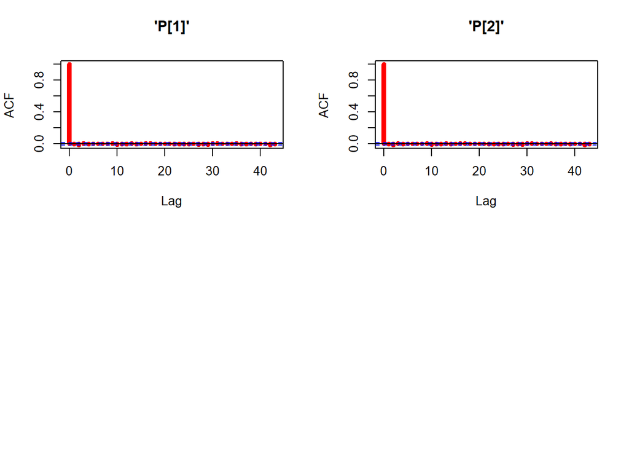

To make some comparisons, I computed also the Maximum Likelihood Esimations. For this data the MLE are slightly different only for sigma.

```
## [1] "Estimated parameters"
```

```
## [1] "Mu"
```

```
## [1] 0.07072738 9.89567184
```

```
## [1] "Sigma"
```

```
## [1] 0.9264997
```

```
## [1] "Normal Weights"
```

```
## [1] 0.5 0.5
```

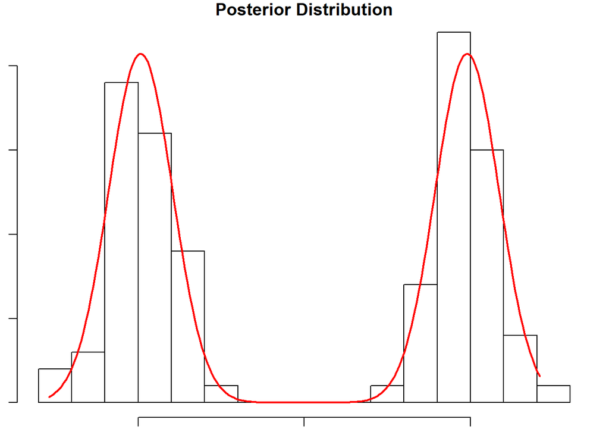

## Our Data

Now that we’ve seen the Bayesian model is able to recover the true values of the parameters, let’s try it on the dataset. As first, let’s run the model using own implementation of the posterior distribution. Each techniques starts from $\mu_{0c}=(537,551)$ as the hyperparameters of the mean, $\sigma^2\=1$ for $\sigma^2$ and $\alpha_1, \alpha_2=(0.6,0.4)$ for the prior of the weights.

```
## [1] "Estimated parameters"
```

```
## [1] "P"
```

```
## [1] 0.6196668
```

```
## [1] "Mu"
```

```
## [1] 536.8507 549.5883
```

```
## [1] "Sigma"
```

```
## [1] 3.307485
```

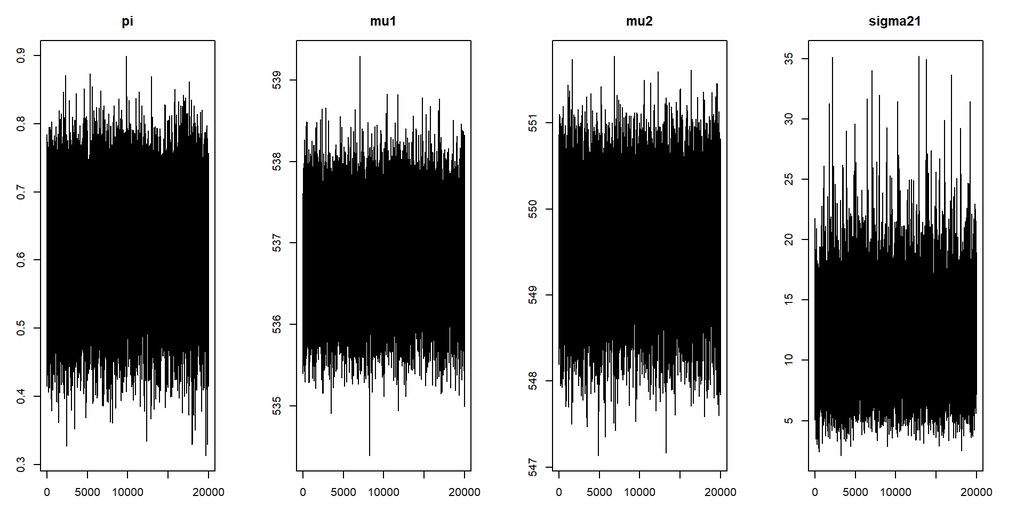

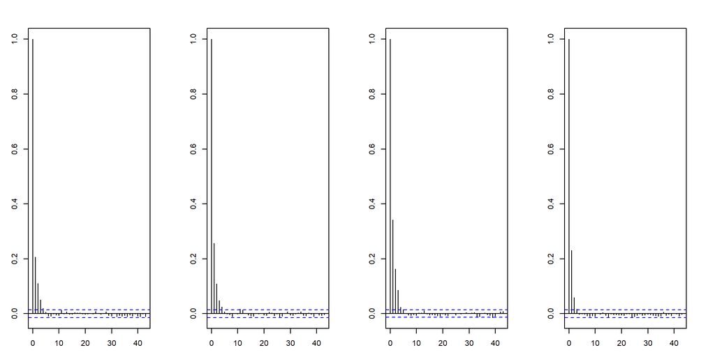

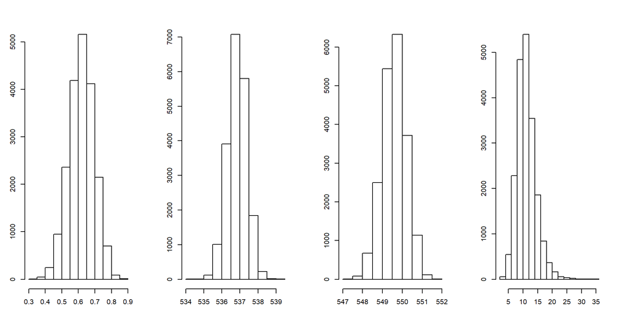

Hence, this procedure converges to a two component normal mixture,as we can see behind

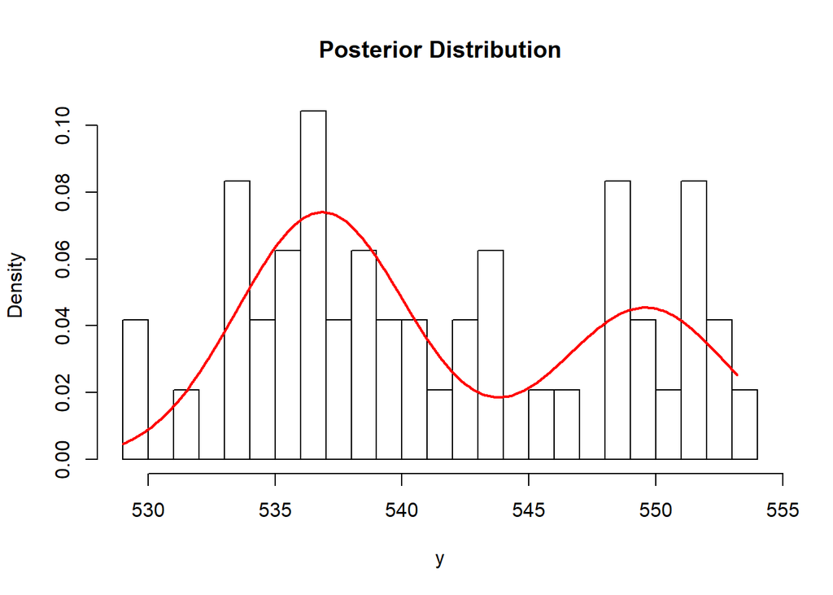

Using Bugs we will have these slightly different results:

For the Gelman Diagnostics, we notice that the model has some difficulty to estimate the posterior for $\sigma^2$, In fact the latter has some convergence problem even at 20000 iterations.

```
## model is syntactically correct
```

```
## data loaded
```

```
## model compiled
```

```
## 1000 updates took 0 s
```

```
## monitor set for variable 'lambda'
```

```
## monitor set for variable 'sigma'
```

```
## monitor set for variable 'P'
```

```
## 30000 updates took 4 s
```

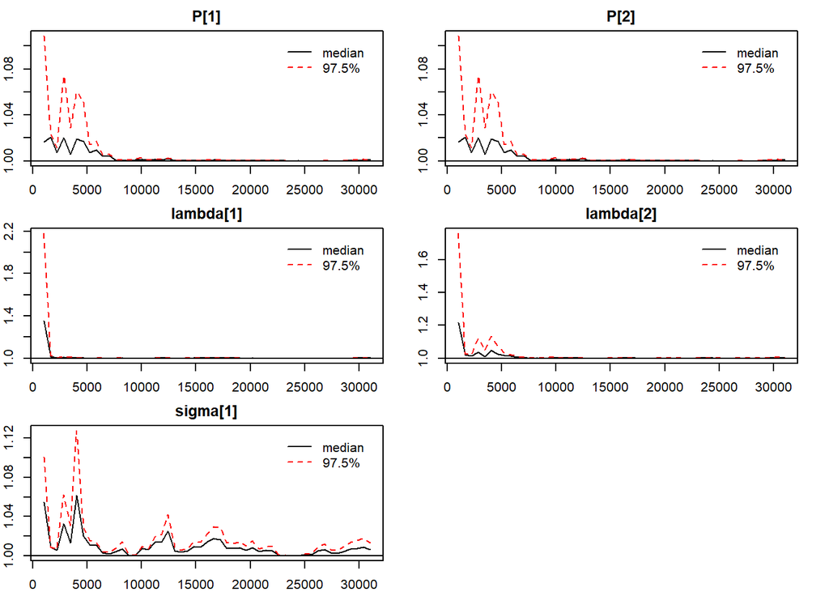

```
##
## Iterations = 1001:31000
## Thinning interval = 1
## Number of chains = 2
## Sample size per chain = 30000
##
## 1. Empirical mean and standard deviation for each variable,
##    plus standard error of the mean:
##
##               Mean      SD  Naive SE Time-series SE
## P[1]        0.6003 0.08652 0.0003532      0.0008312
## P[2]        0.3997 0.08652 0.0003532      0.0008312
## lambda[1] 536.7632 0.94167 0.0038444      0.0115137
## lambda[2] 548.8661 1.28748 0.0052561      0.0154932
## sigma[1]    3.7810 0.63827 0.0026057      0.0112945
##
## 2. Quantiles for each variable:
##
##               2.5%    97.5%
## P[1]        0.4269   0.7593
## P[2]        0.2407   0.5731
## lambda[1] 535.0210 538.6531
## lambda[2] 546.2794 551.2133
## sigma[1]    2.9304   5.4057
```

```
## Potential scale reduction factors:
##
##           Point est. Upper C.I.
## P[1]            1.00       1.00
## P[2]            1.00       1.00
## lambda[1]       1.00       1.00
## lambda[2]       1.00       1.00
## sigma[1]        1.01       1.01
##
## Multivariate psrf
##
## 1
```

However, we can see that the posterior density with the estimated parameters converges to a normal mixture.

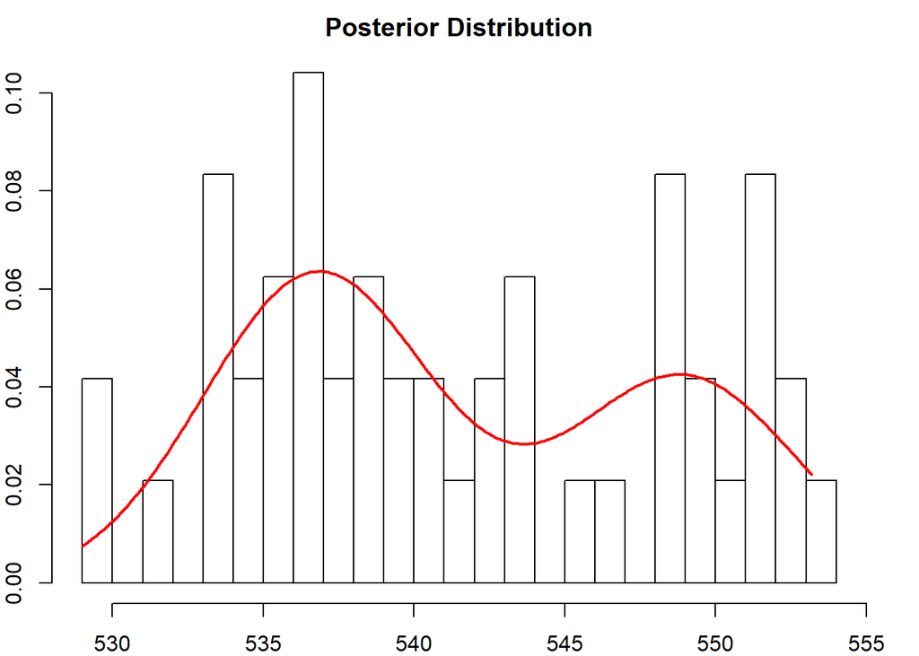

As previously we can check for stationariety, density and correlation of the estimated parameters.

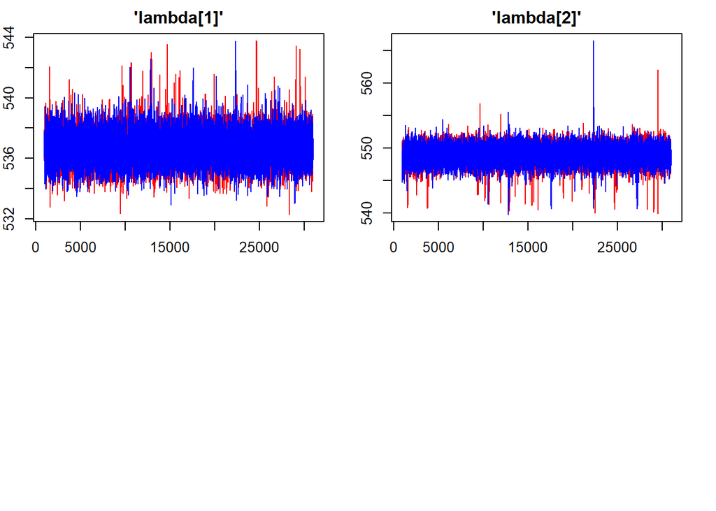

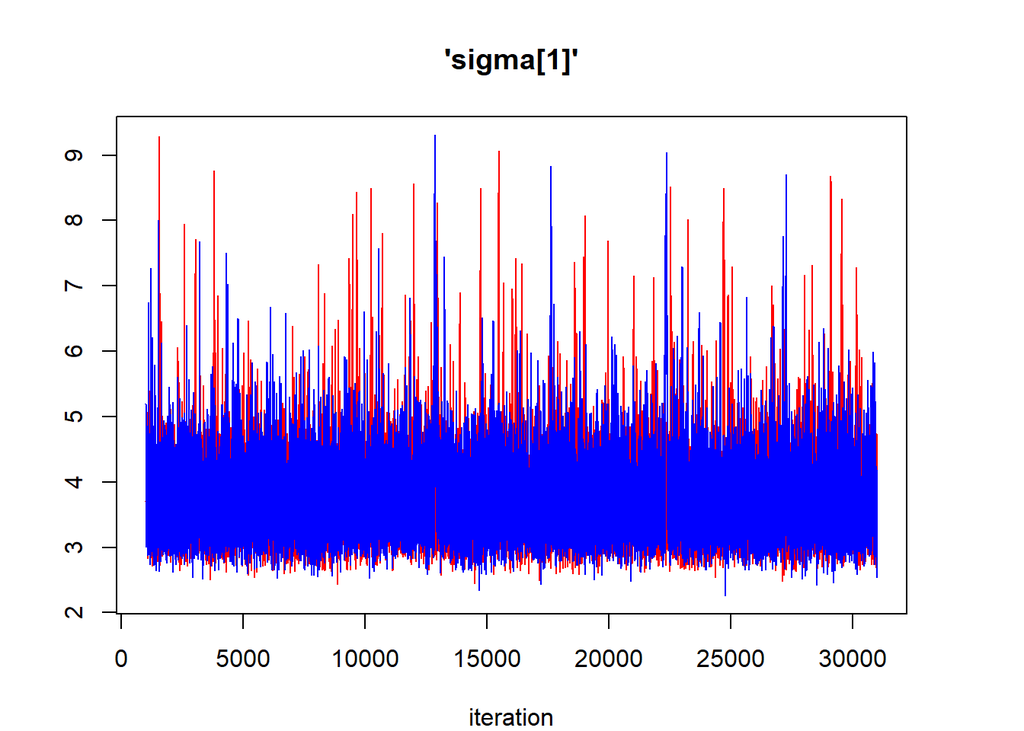

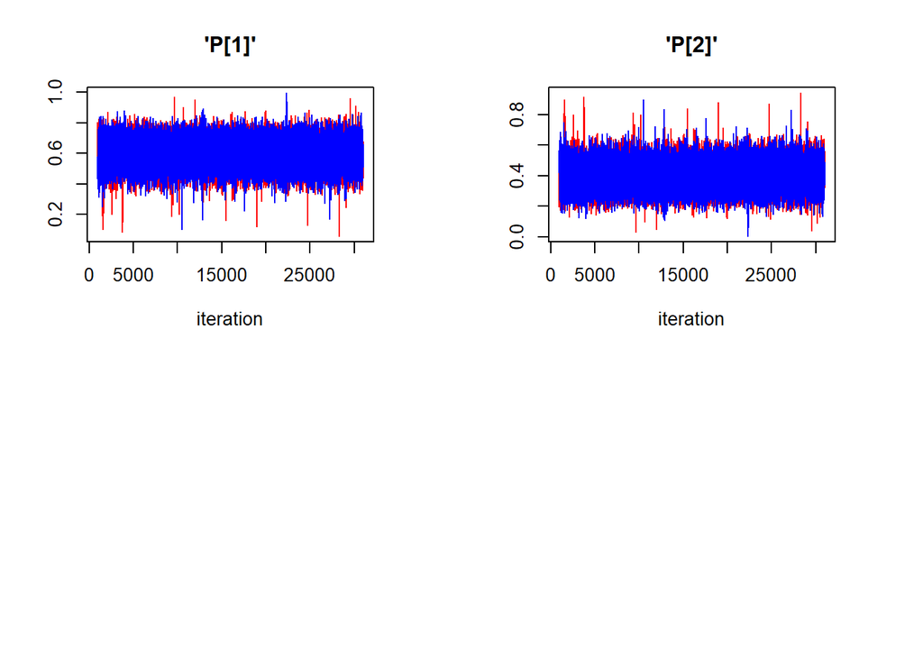

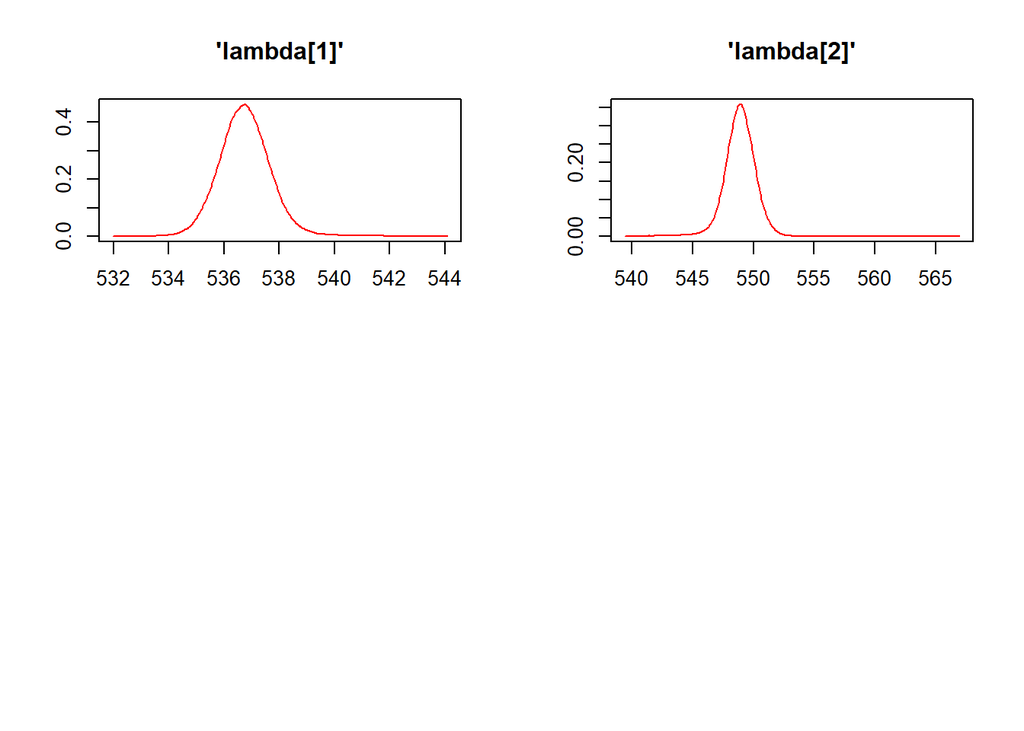

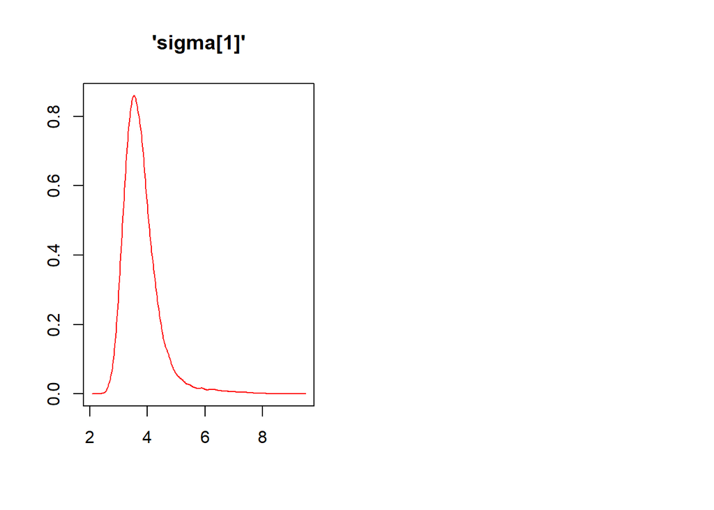

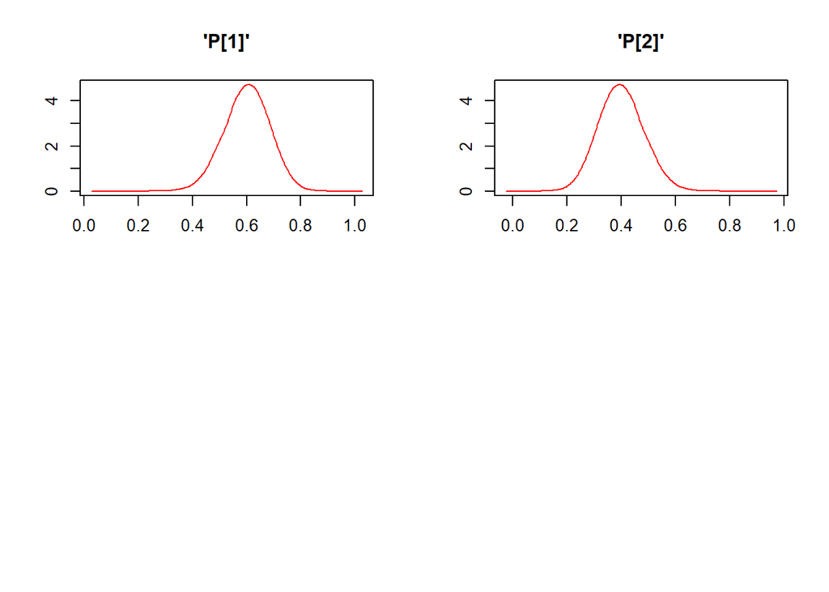

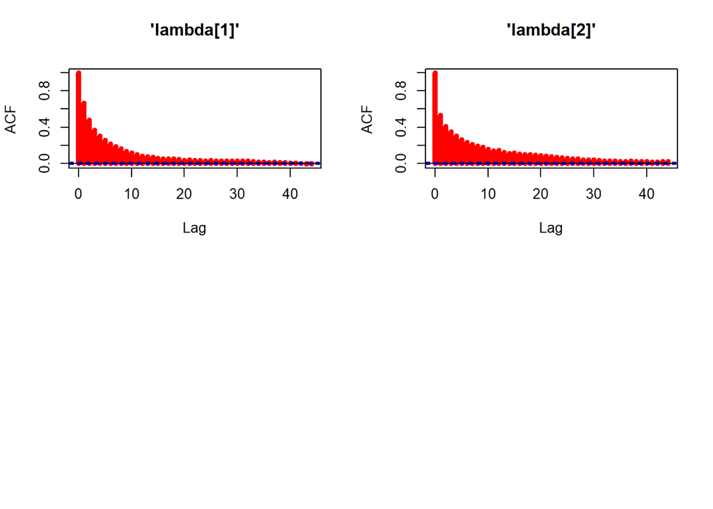